# Connecting R with Git

## Creating a new R project

Step 1:

- Go to Github.com and log in into your account.
- Go to the home page and create a new repository.

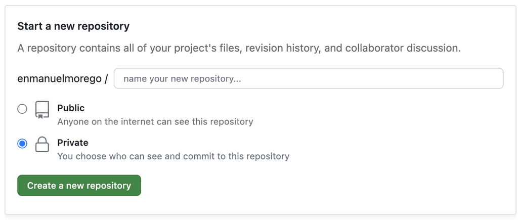

Step 2:

- Once your repo has been created,
- Go to your newly created repo in Github, and copy the Repo address to your clipboard.

[figure not shown]

Step 3:

- Open R Studio, create a New Project and select Version Control.

[figure not shown]

Step 4:

- Select ‘Git Clone a project from a Git repository’.

[figure not shown]

Step 5:

- Clone the Git repo. Paste the repo URL onto ‘Repository URL’
- Enter Project Directory Name.
- Click on Browse to save the repo at your location of choice in your local computer.
- Then click on Create New Project.

[figure not shown]

Once set up, your R projet should look something similar to this. The main features to look for is that you can see the Git tab on the top right corner of your screen. This is where you will interact with Git directly from R. You will be able to push and pull changes. Also, work on your scripts in R and stage, commit and push changes directly from R.

[figure not shown]

## Connecting an existing R project to GitHub

Step 1:

- Open your R project.
- Go to Tools > Version Control > Project Setup…

[figure not shown]

Step 2:

- Set Version control system to ‘Git’.
- A dialog box will open to confirm New Git Repository. Select Yes.
- A dialog box will follow asking to Confirm Restart RStudio. Select Yes.

[figure not shown]

Step 3:

- R would have restarted, and you will be able to see a tab named Git in the same on the top right corner of your Rstudio console.

[figure not shown]

- The contents of your R project will appear on that window, with a question mark next to it. Click on the box and the question mark will change to a green A. This will ‘stage’ that ‘change’ in your Git repository.
- Select all of the items from that list and click on Commit.

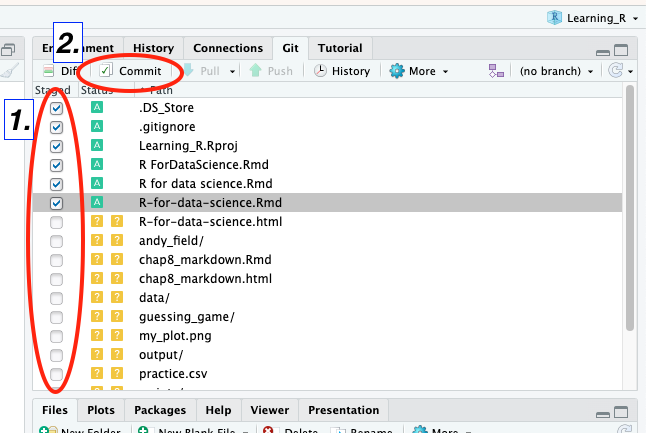

Step 4:

- You will now see a new dialogue box that allows you to review the changes.
- Enter a short but descriptive comment summarising the action you are performing and select commit.
- The Git Commit dialogue box will open indicating which items have been committed. Press close and your Git tab in R studio should now be clear, as all changes are now committed.

[figure not shown]

Step 5:

- Go to GitHub and create a new repository. Recommend using the same name as the R project you are planning to connect to GitHub.
- Once your repository is created, copy the code under the header ‘…or push an existing repository from the command line’

[figure not shown]

Step 6:

- Go back to R and click on Terminal, paste the lines of code copied from GitHub and press Enter.

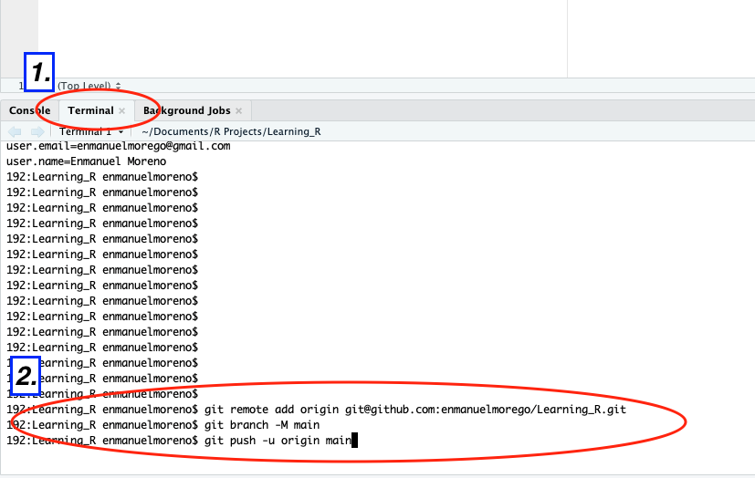

Now go back to GitHub and you should be able to see all of the contents of your R project on GitHub :)

[figure not shown]